# Stock Market News: Sentimental Analysis and Summarization

- Generative AI: Word2Vec, GloVe, SentenceTransformer, Lllama

## Problem Statement

Business Context The prices of the stocks of companies listed under a global exchange are influenced by a variety of factors, with the company's financial performance, innovations and collaborations, and market sentiment being factors that play a significant role. News and media reports can rapidly affect investor perceptions and, consequently, stock prices in the highly competitive financial industry. With the sheer volume of news and opinions from a wide variety of sources, investors and financial analysts often struggle to stay updated and accurately interpret its impact on the market. As a result, investment firms need sophisticated tools to analyze market sentiment and integrate this information into their investment strategies.

## Problem Definition

With an ever-rising number of news articles and opinions, an investment startup aims to leverage artificial intelligence to address the challenge of interpreting stock-related news and its impact on stock prices. They have collected historical daily news for a specific company listed under NASDAQ, along with data on its daily stock price and trade volumes.

As a member of the Data Science and AI team in the startup, you have been tasked with analyzing the data, developing an AI-driven sentiment analysis system that will automatically process and analyze news articles to gauge market sentiment, and summarizing the news at a weekly level to enhance the accuracy of their stock price predictions and optimize investment strategies. This will empower their financial analysts with actionable insights, leading to more informed investment decisions and improved client outcomes.

## Data Dictionary

- Date : The date the news was released
- News : The content of news articles that could potentially affect the company's stock price
- Open : The stock price `(in $)` at the beginning of the day
- High : The highest stock price `(in $)` reached during the day
- Low : The lowest stock price `(in $)` reached during the day
- Close : The adjusted stock price `(in $)` at the end of the day
- Volume : The number of shares traded during the day
- Label : The sentiment polarity of the news content
  - 1: positive
  - 0: neutral
  - -1: negative

## Installing and Importing Necessary Libraries

```python
%pip install --upgrade --force-reinstall sentence-transformers==2.7.0 transformers==4.40.2 bitsandbytes==0.46.0 accelerate==1.7.0 sentencepiece==0.2.0 pandas==2.2.2 numpy==2.0.2 matplotlib==3.10.0 seaborn==0.13.2 torch==2.6.0 scikit-learn==1.6.1
```

[output not shown]

[output cut: 316 more lines]

[output not shown]

```python
%pip install gensim
```

```
Downloading gensim-4.4.0-cp312-cp312-manylinux_2_24_x86_64.manylinux_2_28_x86_64.whl (27.9 MB)
   ━━━━━━━━━━━━━━━━━━━━━━━━━━━━━━━━━━━━━━━━ 27.9/27.9 MB 65.7 MB/s eta 0:00:00
```

```python
# To manipulate and analyze data
import pandas as pd
import numpy as np

# To visualize data
import matplotlib.pyplot as plt
import seaborn as sns

# To used time-related functions
import time

# To parse JSON data
import json

# To build, tune, and evaluate ML models
# from sklearn.ensemble import DecisionTreeClassifier # Incorrecct import
from sklearn.ensemble import GradientBoostingClassifier
from sklearn.ensemble import RandomForestClassifier
from sklearn.tree import DecisionTreeClassifier # Update import replacing commented sklearn.ensemble import

from sklearn.model_selection import GridSearchCV
from sklearn.metrics import confusion_matrix, accuracy_score, f1_score, precision_score, recall_score

# To load/create word embeddings
from gensim.models import Word2Vec
from gensim.models import KeyedVectors
from gensim.scripts.glove2word2vec import glove2word2vec

# To work with transformer models
import torch
from sentence_transformers import SentenceTransformer

# To implement progress bar related functionalities
from tqdm import tqdm
tqdm.pandas()

# To ignore unnecessary warnings
import warnings
warnings.filterwarnings('ignore')
```

```python
# Check library versions
print("pandas:   ", pd.__version__)
print("numpy:    ", np.__version__)
print("seaborn:  ", sns.__version__)
print("torch:    ", torch.__version__)
```

```
pandas:    2.2.2
numpy:     2.0.2
seaborn:   0.13.2
torch:     2.6.0+cu124
```

## Loading the dataset

```python
stock_news = pd.read_csv('https://raw.githubusercontent.com/ShauryaRawat10/Data-Science/main/Generative%20AI/Storage/stock_news.csv', engine='python')
```

```python
stock = stock_news.copy()
```

## Data Overview

```python
stock.head()
```

|  | Date | News | Open | High | Low | Close | Volume | Label |
| --- | --- | --- | --- | --- | --- | --- | --- | --- |
| 0 | 2019-01-02 | The tech sector experienced a significant dec... | 41.740002 | 42.244999 | 41.482498 | 40.246914 | 130672400 | -1 |
| 1 | 2019-01-02 | Apple lowered its fiscal Q1 revenue guidance ... | 41.740002 | 42.244999 | 41.482498 | 40.246914 | 130672400 | -1 |
| 2 | 2019-01-02 | Apple cut its fiscal first quarter revenue fo... | 41.740002 | 42.244999 | 41.482498 | 40.246914 | 130672400 | -1 |
| 3 | 2019-01-02 | This news article reports that yields on long... | 41.740002 | 42.244999 | 41.482498 | 40.246914 | 130672400 | -1 |
| 4 | 2019-01-02 | Apple's revenue warning led to a decline in U... | 41.740002 | 42.244999 | 41.482498 | 40.246914 | 130672400 | -1 |

```python
stock.tail()
```

|  | Date | News | Open | High | Low | Close | Volume | Label |
| --- | --- | --- | --- | --- | --- | --- | --- | --- |
| 344 | 2019-04-30 | Media mogul Oprah Winfrey, known for influenc... | 50.764999 | 50.849998 | 49.7775 | 48.70879 | 186139600 | -1 |
| 345 | 2019-04-30 | European shares fell on Tuesday, with banks u... | 50.764999 | 50.849998 | 49.7775 | 48.70879 | 186139600 | -1 |
| 346 | 2019-04-30 | This article reports that the S&P 500 reached... | 50.764999 | 50.849998 | 49.7775 | 48.70879 | 186139600 | -1 |
| 347 | 2019-04-30 | The Federal Reserve is anticipated to keep in... | 50.764999 | 50.849998 | 49.7775 | 48.70879 | 186139600 | -1 |
| 348 | 2019-04-30 | In the first quarter, South Korea's Samsung E... | 50.764999 | 50.849998 | 49.7775 | 48.70879 | 186139600 | 0 |

```python
stock.shape
```

```
(349, 8)
```

- Total 349 rows and 8 columns in the Stock market dataset

```python
stock.columns
```

```
Index(['Date', 'News', 'Open', 'High', 'Low', 'Close', 'Volume', 'Label'], dtype='object')
```

```python
stock.duplicated().sum()
```

```
np.int64(0)
```

- No duplicates

```python
stock.isnull().sum()
```

|  | 0 |
| --- | --- |
| Date | 0 |
| News | 0 |
| Open | 0 |
| High | 0 |
| Low | 0 |
| Close | 0 |
| Volume | 0 |
| Label | 0 |

**dtype:** int64

- No null values

```python
stock.nunique()
```

|  | 0 |
| --- | --- |
| Date | 71 |
| News | 349 |
| Open | 70 |
| High | 70 |
| Low | 71 |
| Close | 71 |
| Volume | 71 |
| Label | 3 |

**dtype:** int64

- News columns is always unique
- Label (Sentiment) has 3 categories

```python
stock.info()
```

```
<class 'pandas.core.frame.DataFrame'>
RangeIndex: 349 entries, 0 to 348
Data columns (total 8 columns):
 #   Column  Non-Null Count  Dtype
---  ------  --------------  -----
 0   Date    349 non-null    object
 1   News    349 non-null    object
 2   Open    349 non-null    float64
 3   High    349 non-null    float64
 4   Low     349 non-null    float64
 5   Close   349 non-null    float64
 6   Volume  349 non-null    int64
 7   Label   349 non-null    int64
dtypes: float64(4), int64(2), object(2)
memory usage: 21.9+ KB
```

- 6 Columns are of numerical data type. 2 are categorical

## Convert Date to DateTime format

```python
stock['Date'] = pd.to_datetime(stock['Date'])
```

```python
stock.dtypes
```

|  | 0 |
| --- | --- |
| Date | datetime64[ns] |
| News | object |
| Open | float64 |
| High | float64 |
| Low | float64 |
| Close | float64 |
| Volume | int64 |
| Label | int64 |

**dtype:** object

```python
pd.set_option('display.float_format', '{:.2f}'.format)
stock.describe()
```

|  | Date | Open | High | Low | Close | Volume | Label |
| --- | --- | --- | --- | --- | --- | --- | --- |
| count | 349 | 349.00 | 349.00 | 349.00 | 349.00 | 349.00 | 349.00 |
| mean | 2019-02-16 16:05:30.085959936 | 46.23 | 46.70 | 45.75 | 44.93 | 128948236.10 | -0.05 |
| min | 2019-01-02 00:00:00 | 37.57 | 37.82 | 37.30 | 36.25 | 45448000.00 | -1.00 |
| 25% | 2019-01-14 00:00:00 | 41.74 | 42.24 | 41.48 | 40.25 | 103272000.00 | -1.00 |
| 50% | 2019-02-05 00:00:00 | 45.97 | 46.03 | 45.64 | 44.60 | 115627200.00 | 0.00 |
| 75% | 2019-03-22 00:00:00 | 50.71 | 50.85 | 49.78 | 49.11 | 151125200.00 | 0.00 |
| max | 2019-04-30 00:00:00 | 66.82 | 67.06 | 65.86 | 64.81 | 244439200.00 | 1.00 |
| std | NaN | 6.44 | 6.51 | 6.39 | 6.40 | 43170314.92 | 0.72 |

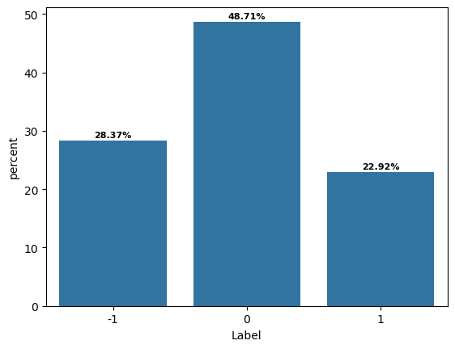

```python
ax = sns.countplot(data=stock, x='Label', stat="percent")

# Add percentage values at the top of each bar
total = len(stock)
                                       # Total number of items in the dataset
for p in ax.patches:
    height = p.get_height()
    ax.annotate(f'{height:.2f}%',                            # Display percentage with 2 decimals
                (p.get_x() + p.get_width() / 2., height),    # Position at the top of the bar
                ha='center', va='center',                    # Alignment
                fontsize=8, color='black', fontweight='bold', # Styling
                xytext=(0, 5), textcoords='offset points')   # Adjust text position
```

For the reported news:

- 48.7% with Neural Sentiment
- 28.4% with Negative Sentiment
- 22.9% with positive sentiment

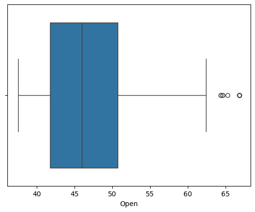

```python
sns.boxplot(data=stock, x='Open')
```

- Most of the stocks with 'Opening Price' are between 35 - 63 unit dollars, with few outliers of 65+

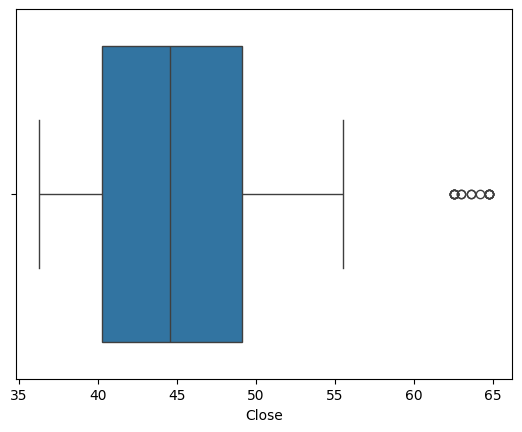

```python
sns.boxplot(data=stock, x='Close')
```

- Closing price for stocks are between 37 to 55 unit dollar. Outliers of 63-65 exists

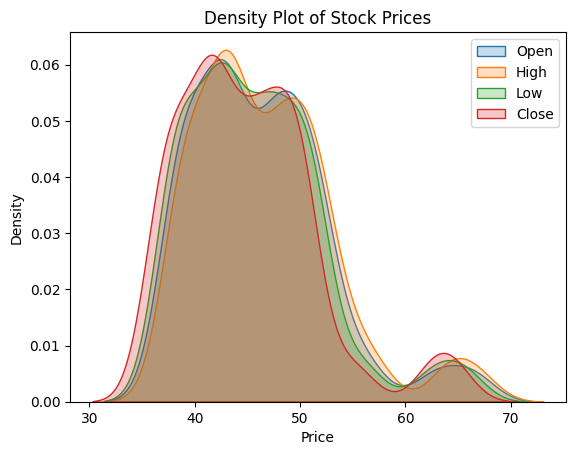

```python
# Density Plot of Price (Open,High,Low,Close)
for i in ["Open","High","Low","Close"]:
    sns.kdeplot(stock[i], label=i, shade=True)
plt.xlabel("Price")
plt.ylabel("Density")
plt.title("Density Plot of Stock Prices")
plt.legend()
plt.show()
```

- Stock Price mostly landed in the 40-50 range

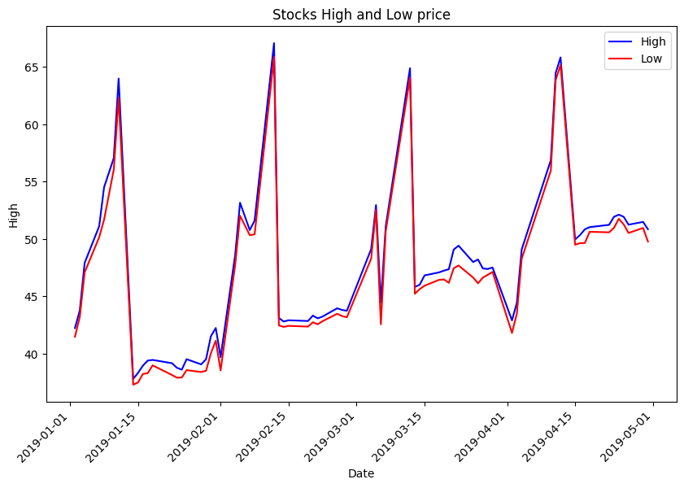

```python
plt.figure(figsize=(10, 6))
sns.lineplot(x='Date', y='High', data=stock, color='blue', label='High')
sns.lineplot(x='Date', y='Low', data=stock, color='red', label='Low')
plt.title('Stocks High and Low price')
plt.xticks(
    rotation=45,                     # rotate for readability
    ha='right'                       # right-align the labels
)
plt.show()
```